# urbnmapr

## A simple solution to a common problem

urbnmapr makes a few variations of the same basic map.

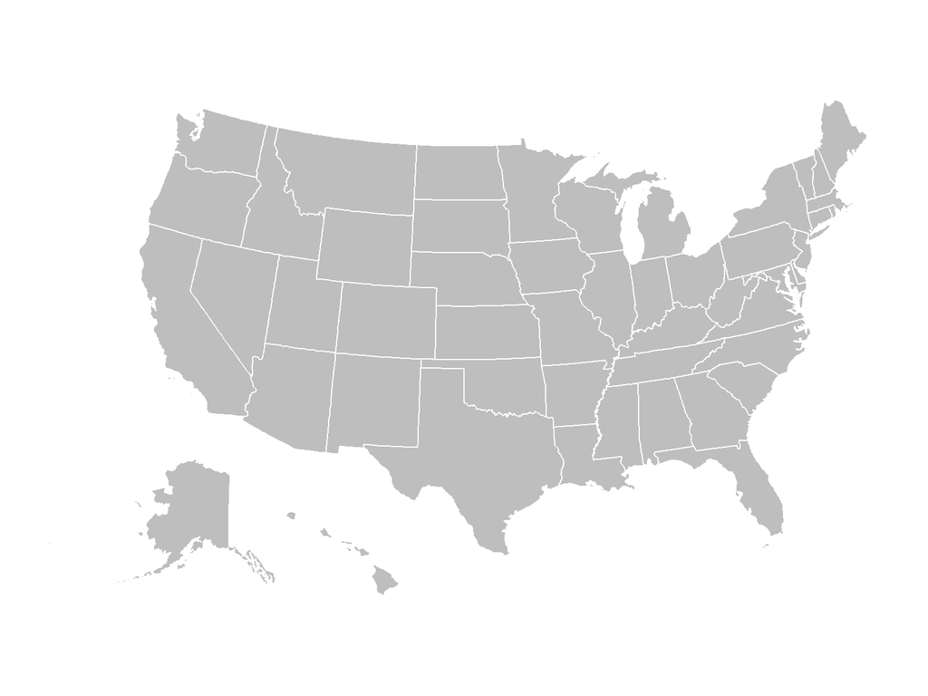

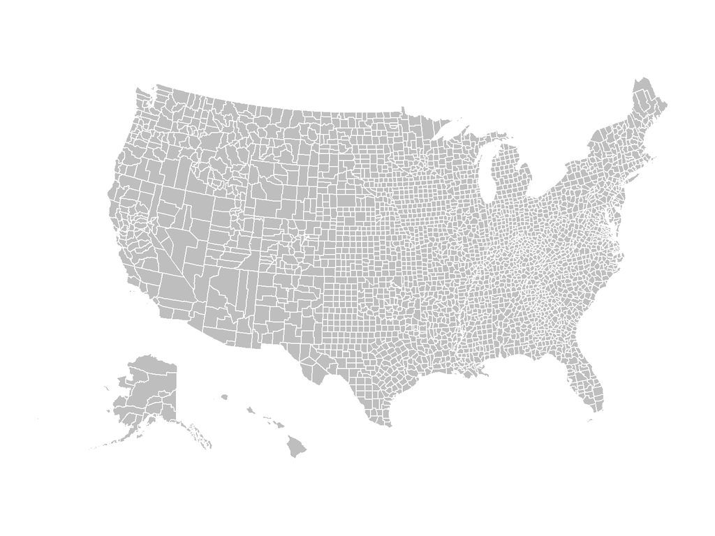

# How it works

## Installation

The package lives on GitHub. The `devtools` package makes it easy to install straight from the source.

```r
devtools::install_github("UrbanInstitute/urbnmapr")
```

## Functionality

```r
states <- get_urbn_map(map = "states", sf = TRUE)
```

```
##   state_fips state_abbv state_name                       geometry
## 1         01         AL    Alabama MULTIPOLYGON (((1150023 -15...
## 2         02         AK     Alaska MULTIPOLYGON (((-1273178 -2...
## 3         04         AZ    Arizona MULTIPOLYGON (((-1386136 -1...
## 4         05         AR   Arkansas MULTIPOLYGON (((482001 -928...
## 5         06         CA California MULTIPOLYGON (((-1717278 -1...
```

You can merge your data onto this dataframe to make choropleth maps.

```r
geographic_data <- left_join(states, statedata,
                             by = "state_name")
```

## Making maps

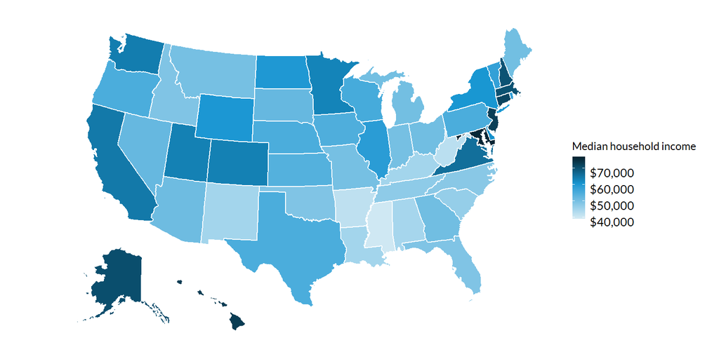

```r
ggplot() +
  geom_sf(data = geographic_data,
          mapping = aes(fill = medhhincome),
          color = "white") +
  scale_fill_gradientn(labels = scales::dollar) +
  coord_sf(datum = NA) +
  urbnthemes::theme_urbn_map() +
  labs(fill = "Median household income")
```

## Extensions

Mapping individual states

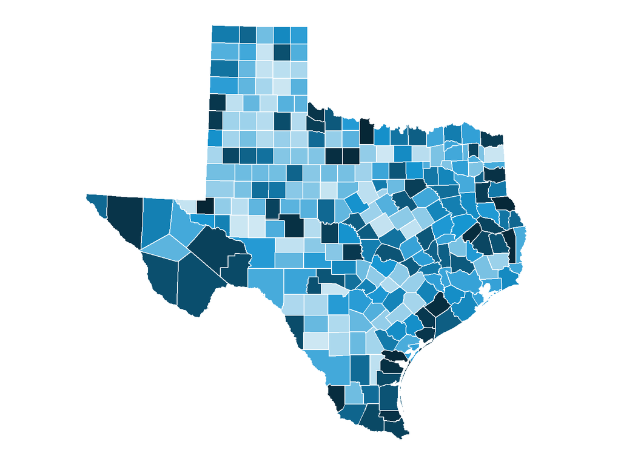

Custom layouts for specific projects

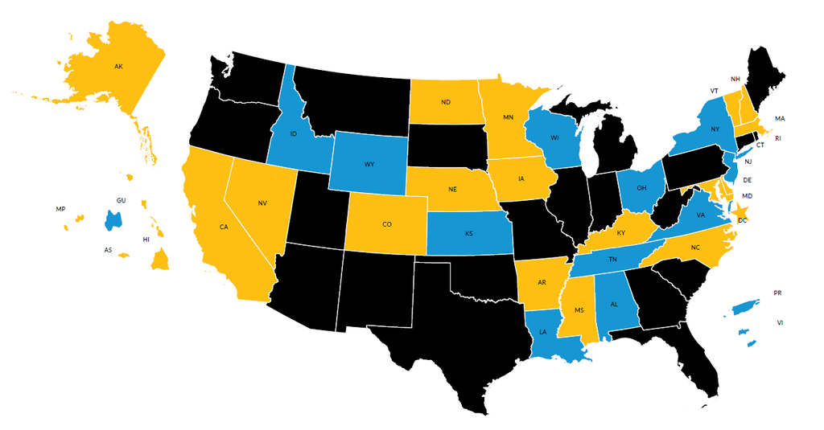

## For more information

Visit the [urbnmapr GitHub page](https://github.com/UrbanInstitute/urbnmapr) for more detailed instructions.

The Urban Institute mapping guide is currently in progress!

# Why R?

## Why R?

- Reproducibility
- Make the same map 100 times
- It’s free
- Geospatial analysis in R is constantly evolving

# Why a package?

## Why a package?

- Portable
- Lowers the barrier to entry
- Push updates when we need to
- Cool hex stickers

# R @ Urban

## R @ Urban

We create tools to help researchers do their jobs more efficiently- whether it is running trainings, building packages, or writing detailed guides.

You can follow along:

- Check out our [website](https://ui-research.github.io/r-at-urban/)
- Sign up for the [urbnverse list serve](https://app.smartsheet.com/b/form/9029a0a8254e4044a52cdebaebe343bf) (we won’t email you more than once a month!)
- Look for new posts on [Data@Urban](https://medium.com/@urban_institute), the Urban Institute’s behind-the-scenes blog on data, code, and more.
- Email me at sstrochak@urban.org for more information!